# Final Project: Assessing COVID-19 Impacts on Voter Registration in 2020

Author

Matthew O’Stricker

# 1. Introduction

COVID-19 took the world by storm in 2020 and greatly altered so many key aspects of our daily lives. Outside of the many lives that were taken by the disease, the global pandemic created a shift in the very fabric of American democracy due to the implications it had on the U.S. presidential elections. The U.S. presidential election is a historic staple in American democracy that ultimately decides who will become the leader of the “free world” for the next four years. With the U.S. seeing a constant slight rise in recent years, the expectation is that there would be a constant rise in voter registration in the presidential elections.

To better analyze to see if this occurred and what caused the results that will be found, I plan to answer the research question “What change, if any, occurred to the way voters registered in Florida pre-pandemic - Janurary through February - and post-pandemic - March through April - in 2020?” To answer the question, I plan to use the `voter_registration` dataset from fivethirtyeight and the `covid_cases` dataset that has the covid cases recorded in 2020 in the United States from Our World in Data to analyze the voter registration numbers for each state. To measure the impact, I plan to compare the monthly from Jan-April trends for certain states during the 2020 election cycle to see if I can spot any key differences. I plan to track the change in these months by taking a look at the change in in-person and remote voting during the period.

Please note, per the CDC, where the COVID-19 cases data was collected, “New York State’s reported case and death counts do not include New York City’s counts as they separately report nationally notifiable conditions to CDC.” This explains why there is info for NY and NYC.

Additionally, only 11 states and Washington D.C. will be included in the datasets because those were the only places where fivethirtyeight was able to get data on new registered voters. I could not find any supplemental data for the other states. However, I believe the 12 jurisdictions will be able to accurately answer the aformentioned question.

In order to conduct effective regression and residual analysis, I plan to use the state of Florida, with a focus on its counties, as a key example for that portion of my final project. Since Florida was the state with the most data accessible, it will serve as the example that can serve as the answer to the research question. I specified my research question to focus on Florida for this reason and hope the answer can potentially serve as the foundation for any future research questions and analysis that focuses on COVID-19’s impact other states during 2020.

Take a look at the main data I will be analyzing about the counties in Florida during the first four months of 2020:

```
# A tibble: 6 × 7
  County   Month postcovid inperson remote   pip MedianIncome
  <chr>    <fct>     <dbl>    <dbl>  <dbl> <dbl>        <dbl>
1 Alachua  Apr           1      103     53  66.0        50089
2 Baker    Apr           1       19     12  61.3        62299
3 Bay      Apr           1      123    103  54.4        56483
4 Bradford Apr           1        7      7  50          43580
5 Brevard  Apr           1      305    289  51.3        59359
6 Broward  Apr           1     1266    556  69.5        60922
```

# 2. Exploratory Data Analysis

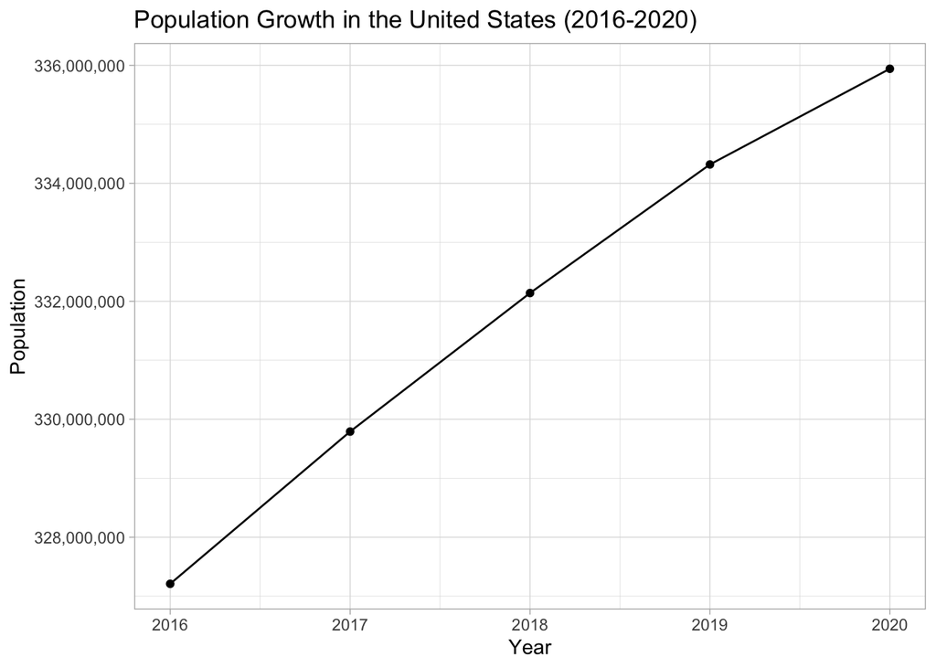

**Figure 1. Population Growth in the United States from 2016 to 2020**

Figure 1 belows shows that the population in the United States has been growing at a steady rate from 2016 to 2020. The constant growth leads me to hypothesize that there will be a growth in new voter registration numbers due to larger population in the United States. Any dramatic shifts in registration numbers will be alarming and a cause for investigation.

States/Districts Included in my Datasets:

1. Arizona (AZ)
2. California (CA)
3. Colorado (CO)
4. Washington D.C. (DC)
5. Delaware (DE)
6. Florida (FL)
7. Georgia (GA)
8. Illinois (IL)
9. Maryland (MD)
10. North Carolina (NC)
11. Texas (TX)
12. Virginia (VA)

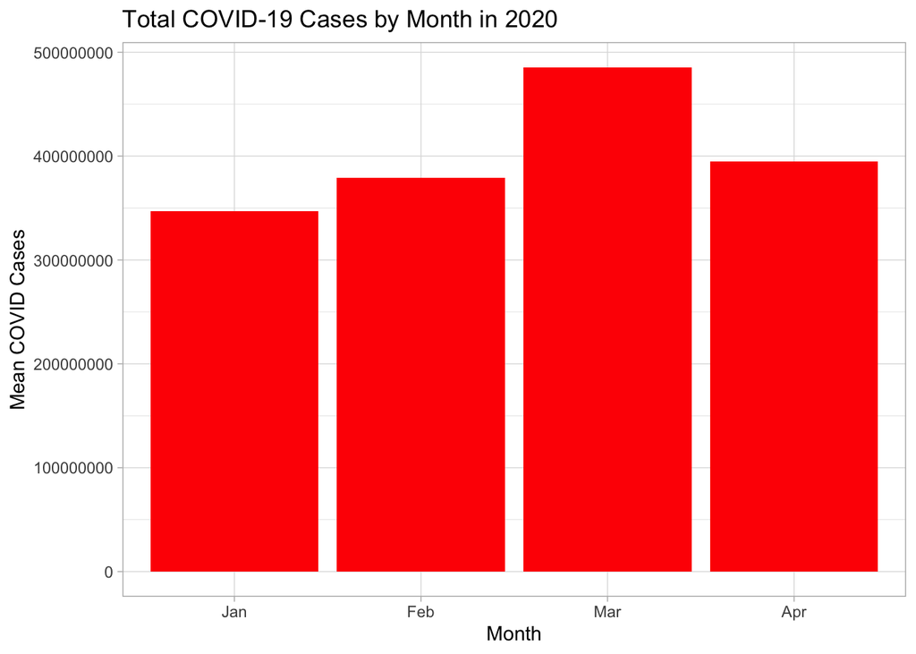

**Figure 2. Total COVID-19 Cases by Month in 2020**

After finding the population growth, I wanted to do a dive on the year 2020. First, I graphed Figure 2, which shows the total COVID-19 cases by month for the states included in the datasets, to gauge the amount of cases and their growth trends. It seems the total amount of cases was steadily growing and peaked during the month of March. Since I am able to see there was a large amount of cases during the month, I will want to look at the voter registration during the months to see if I can spot anything of significance. I hypothesize there will be a decline in voter registrations from the month of March to April in 2020.

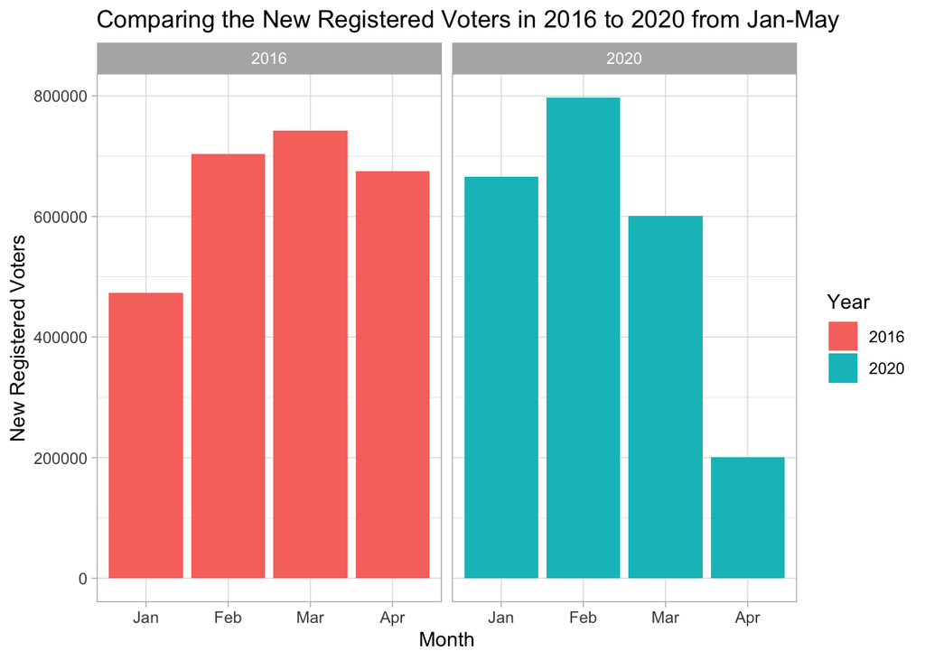

As we can see from Figure 3, there was quite a shift that occurred. In 2016, there was an expected trend of voter registration steadily increasing for the first three months before experiencing a marginal decline in April. However, in 2020, there was an extremely high peak in February that was followed by a decent drop in March and a massive decline in April. Figure 3 highlights the ever-apparent result: some factor contributed to the drastic decrease in voter registrations from March to April in 2020 that prevented the chart from following the similar trend from 2016. I hypothesize that COVID-19 was a key contributor to the drastic decline in voter registration from March to April in 2020. Now, begins the quest of running analysis to identity any potential correlation between Covid-19 cases and voter registration.

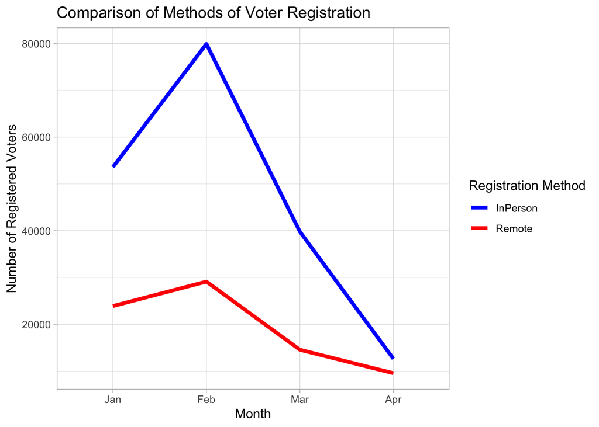

**Figure 4: Comparison of methods of Voter Registration**

Lastly, I generated a colored scatterplot that displayed the relationship between the percentage of the median income of citzens in Florida counties and in-person voters from January to April in 2020.

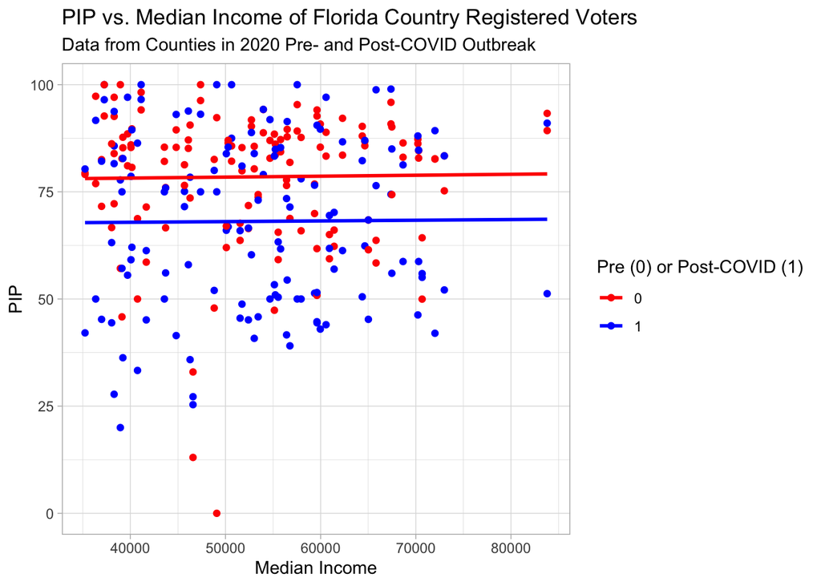

**Figure 5: Regression Analysis of PIP and Median Income**

# 3. Multiple linear regression

## 3.1 Methods

For my multiple linear regression model, I will feature the following variables:

- Outcome variable y = pip or the percentage of in-person voters
- Numerical explanatory variable MedianIncome = Median income of citizens in the county
- Categorical explanatory variable postcovid = defines the period that was pre-covid (0) and the period that is post-covid (1)

Note: the unit of analysis is county since each row is a specific county in Florida.

## 3.2 Model Results

```
# A tibble: 4 × 7
  term                   estimate std_error statistic p_value lower_ci upper_ci
  <chr>                     <dbl>     <dbl>     <dbl>   <dbl>    <dbl>    <dbl>
1 intercept                  77.3      7.63    10.1     0         62.3     92.4
2 postcovid                 -10.1     10.8     -0.933   0.351    -31.3     11.2
3 MedianIncome                0        0        0.156   0.876      0        0
4 postcovid:MedianIncome      0        0       -0.03    0.976      0        0
```

## 3.3 Interpreting the regression table

$$y = b_0 + b_1(postcovid) + b_2(MedianIncome) + b_3(postcovid)*(MedianIncome)$$

## 3.4 Inference for multiple regression

There are two null hypotheses that I will assess based on the information from the regression table. The first is that there is no relationship between postcovid and PIP, which is the outcome variable.

**Null Hypothesis #1**

$$H_0 :β_{prct} = 0$$
$$H_A :β_{prct} ≠ 0$$

When assessing the first hypothesis based off of the information from the regression table, it is quite clear that there is not enough information to support there being a strong relationship between the two variables. The 95% confidence interval spans to cover both negative and positive numbers, which hurts the clarity of the data. Further, the p-value was non significant as it way above the .05 threshold, which caused me to fail to reject the null hypothesis.

**Null Hypothesis #2**

For the second null hypothesis, I that there is no relationship between postcovid and MedianIncome. Essentially, the null hypothesis is stating there is no relationship between COVID-19 and the MedianIncome of citizens in different Florida counties. For the 95% confidence interval, postcovid:MedianIncome (pCmi) occupies only 0.000, gives me little faith that the relationship between the variables in significant. Further, the p-value, which is 0.976, is greater than 0.05 and leads to another failure to reject the hypothesis.
$$H_0 :β_{pCmi} = 0$$

$$H_A :β_{pCmi} ≠ 0$$

## 3.5 Residual Analysis

To ensure that I can fully trust the results of the linear regression, I will need to some residual analysis on the data. Further, the analysis will help e detect any outliers or other points that could skew my regression model.

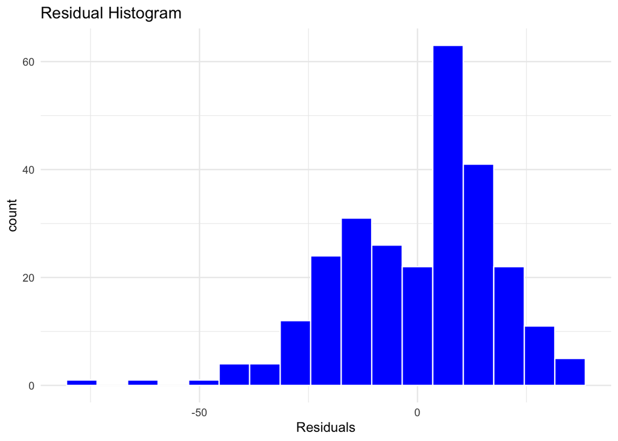

**Figure 6. Histogram of residuals for my statistical model**

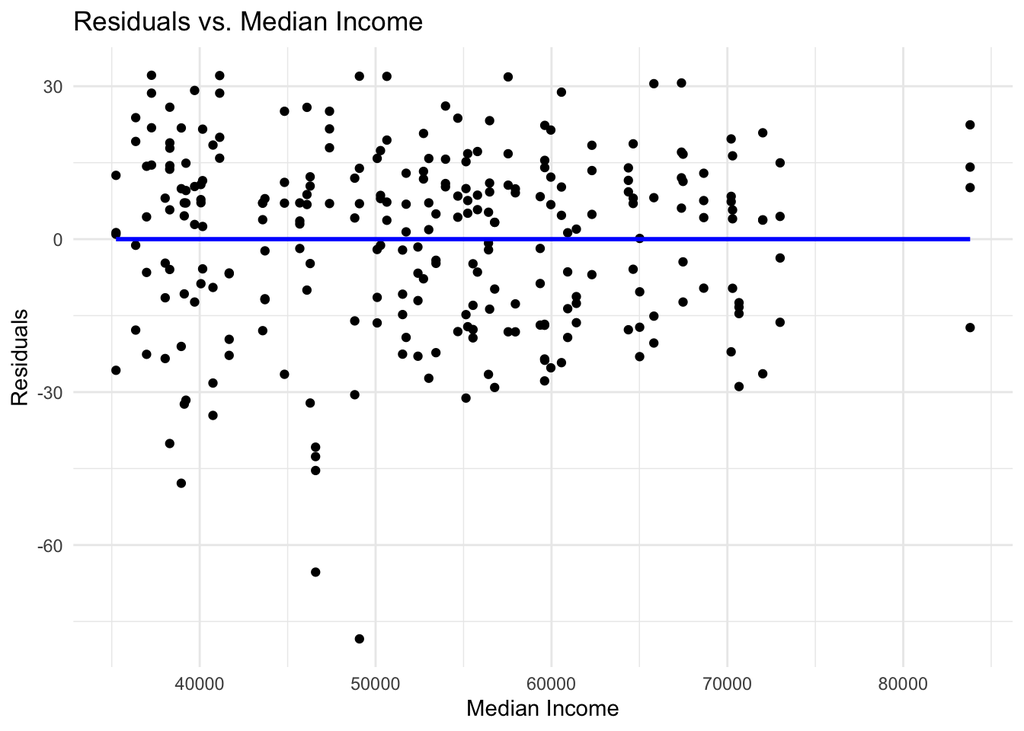

**Figure 7. Scatterplots of residuals against the numeric explanatory variable**

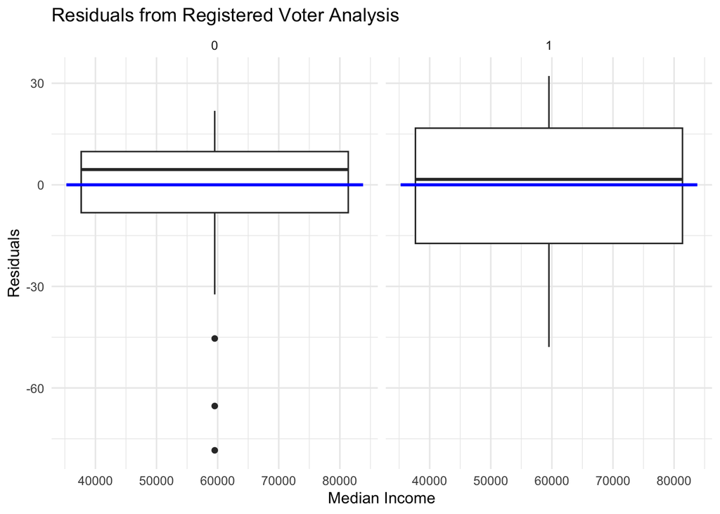

**Figure 8. Boxplot of residuals for Median Incomes pre- and post-COVID outbreak**

# 4. Discussion

## 4.1 Conclusions

In regards to figuring out 2020’s stark decline in voter registration in the month’s of March and April that ran counter to the expected positive trends from previous years, the statistical analysis has provided some interesting results. Starting with the regression analysis that was used to understand the relationshipo between the variables of PIP, MedianIncome, and postcovid, there was two main takeaways. First, there was a 10.076% decrease in PIP following the COVID-19 outbreak, which is the `1` in the categorical variable of postcovid. Second, I did not find a significant relationship between MedianIncome and the PIP nor could I find a substantial interaction between the two variables postcovid and MedianIncome.

Moving to the hypothesis testing, the two null hypotheses were inconclusive and held little significance. Issues included non-significant p-values, confidence intervals spanning 0.000, and the other confidence interval being spanned over positive and negative values.

## 4.2 Limitations

There were a variety of limitations that made this process of answering this question so difficult. First, only 11 (12 if you count D.C.) of the 50 states had accessible data on voter registration from 2020. The lack accessibility reduced my reach substantially and forced me to continue to pivot until I came across certain state sites that had bits and pieces of information about their voter registrants. Another main issues was that there was no premade data set featuring information on voter registration and COVID-19 cases, which led to the creation of plenty of datasets that were quite time-consuming to complete. Additionally, the imbalance of data online made it harder to generate certain charts as the data was largely dominated by COVID data points since a greater amount of funding was generated for those efforts. The lack of complete data by states is quite ludicrous and barred me from truly being able to get down and truly establish how COVID impacted the democracy of the American people.

## 4.3 Further questions

While my main desire at the onset was to extend this analysis across the country and present similar questions to those citizens and aggregate the data to have a holistic perspective of the country’s full impact on the 2020 election. I would want to analyze other variables such as age, gender, or race played in a role in a person’s remaining in the percentage that is still able to vote in-person. It could also be a great question to see if the change in voter registration in 2020 created a long-term trend in voting that has changed how certain citizens vote.

# 5. Citations and References

1. Hauck, Grace et al. *Five months in: A timeline of how COVID-19 has unfolded in the US.* USA Today, June 23, 2020. https://www.usatoday.com/in-depth/news/nation/2020/04/21/coronavirus-updates-how-covid-19-unfolded-u-s-timeline/2990956001/)
2. Rogers, Kaliegh and Rakich, Nathaniel. *Voter Registrations Are Way, Way Down During The Pandemic.* FiveThirtyEight, June 26th, 2020. https://fivethirtyeight.com/features/voter-registrations-are-way-way-down-during-the-pandemic/
3. Florida Department of State. *Voter Registration Reports*. Florida Division of Elections. November 17, 2023. https://dos.fl.gov/elections/data-statistics/voter-registration-statistics/voter-registration-reports/
4. Mathieu, Edouard et al. *Coronavirus (COVID-19) Cases*. 2020. https://ourworldindata.org/covid-cases
5. Macrotrends. *U.S. Population Growth Rate 1950-2023*. 2023. https://www.macrotrends.net/countries/USA/united-states/population-growth-rate
6. Division of Public Statistics and Performance Management. *Median Household Income*. 2023. https://www.flhealthcharts.gov/ChartsDashboards/rdPage.aspx?rdReport=NonVitalIndRateOnly.Dataviewer&cid=293
7. Strauss, Valerie. *What the numbers really tell us about America's public schools*. Washington Post, March 2017. _https://www.washingtonpost.com/news/answer-sheet/wp/2017/03/06/what-the-numbers-really-tell-us-about-americas-public-schools/?noredirect=on&utm_term=.d9a5b415678d[↩︎](https://moderndive.github.io/moderndive_labs/static/term_project/resubmission_example.html#fnref1)